# Assignment 3

```r
library(Matrix)
library(mlmRev)
library(ggplot2)
library(nlme)
library(lme4)
library(lmerTest)
library(performance)
library(DHARMa)
library(merTools)
library(glmmTMB)
library(purrr)
library(broom.mixed)
library(pbkrtest)
library(patchwork)
```

Input the data from the package and transform the data to the specific way and scale the numeric predictor.

```r
## BMB: don't call your data 'data' (or any other name of a built-in
##  function). Usually works, but occasionally leads to hard-to-debug errors
data<-mlmRev::ScotsSec
## BMB: don't use View() in non-interactive settings
## View(data)
data$social<-as.factor(data$social)
data$primary<-as.factor(data$primary)
data$sex<-as.factor(data$sex)
data$verbal_scale<-scale(data$verbal)
```

## a

setting attain as the response variable and social, sex, verbal as the fixed effects, in addition with the random effect with the primary as group variable(random slope effect).

```r
model_1<-lmerTest::lmer(attain~verbal_scale+sex+social+(verbal_scale+sex+social|primary),data,REML = TRUE)
```

```
boundary (singular) fit: see help('isSingular')
```

## b.

We have to check whether the model is sigular fit(too complex random effects overfitted)

```r
lme4::isSingular(model_1)
```

```
[1] TRUE
```

```r
performance::check_singularity(model_1) ## why the result is different?
```

```
[1] FALSE
```

And then the model is sigular fitted, fixed by method 1 and method 2

```r
# Method1
# we use the summary() to find the smallest variance of the random effect estimators is verbal_scale, 0.0210
# or by VarCorr()
varcor_radomeffecr<-lme4::VarCorr(model_1)
pca<-lme4::rePCA(model_1)

# the variable corresponding to the largest absolute value in the last columne of the eigenvector matrix is the verbal_scale, same as method 1
model_2<-lmerTest::lmer(attain~verbal_scale+sex+social+(sex+social|primary),data,REML = TRUE)
```

```
boundary (singular) fit: see help('isSingular')
```

```r
# as the warnings, need to change the formate too simple
model_2new<-lmerTest::lmer(attain~verbal_scale+sex+social+(0+sex+social|primary)+(1|primary),data,REML = TRUE)
```

```
boundary (singular) fit: see help('isSingular')
```

```r
isSingular(model_2new)
```

```
[1] TRUE
```

```r
lme4::VarCorr(model_2new)
```

```
 Groups    Name        Std.Dev. Corr
 primary   sexM        0.00000
           sexF        0.38298     NaN
           social1     0.08469     NaN -0.997
           social20    0.37815     NaN -0.585  0.610
           social31    0.53785     NaN -0.727  0.703 -0.131
 primary.1 (Intercept) 0.36898
 Residual              2.00307
```

```r
lme4::rePCA(model_2new)
```

```
$primary
Standard deviations (1, .., p=6):
[1] 3.125217e-01 2.200096e-01 1.842068e-01 2.850124e-03 1.345306e-04
[6] 3.228573e-18

Rotation (n x k) = (6 x 6):
              [,1]          [,2] [,3]          [,4]          [,5]          [,6]
[1,] -1.110223e-16  5.551115e-17    0 -1.973465e-15 -4.179579e-15  1.000000e+00
[2,] -5.532531e-01 -3.709567e-01    0  3.075108e-02 -7.452224e-01 -2.997602e-15
[3,]  1.201184e-01  8.750852e-02    0 -9.736605e-01 -1.729133e-01 -2.636780e-15
[4,]  1.105722e-01  8.435755e-01    0  1.773100e-01 -4.946871e-01 -1.776357e-15
[5,]  8.168576e-01 -3.783038e-01    0  1.400025e-01 -4.123460e-01 -1.332268e-15
[6,]  0.000000e+00  0.000000e+00    1  0.000000e+00  0.000000e+00  0.000000e+00

attr(,"class")
[1] "prcomplist"
```

```r
# Then discard the "social" random effect variable.
model_3<-lmerTest::lmer(attain~verbal_scale+sex+social+(sex|primary),data,REML = TRUE)
lme4::isSingular(model_3)
```

```
[1] FALSE
```

## c.

Diagnostics on the fitted model”model_3”

[output not shown]

[figure not shown]

```r
performance::check_model(model_3)
```

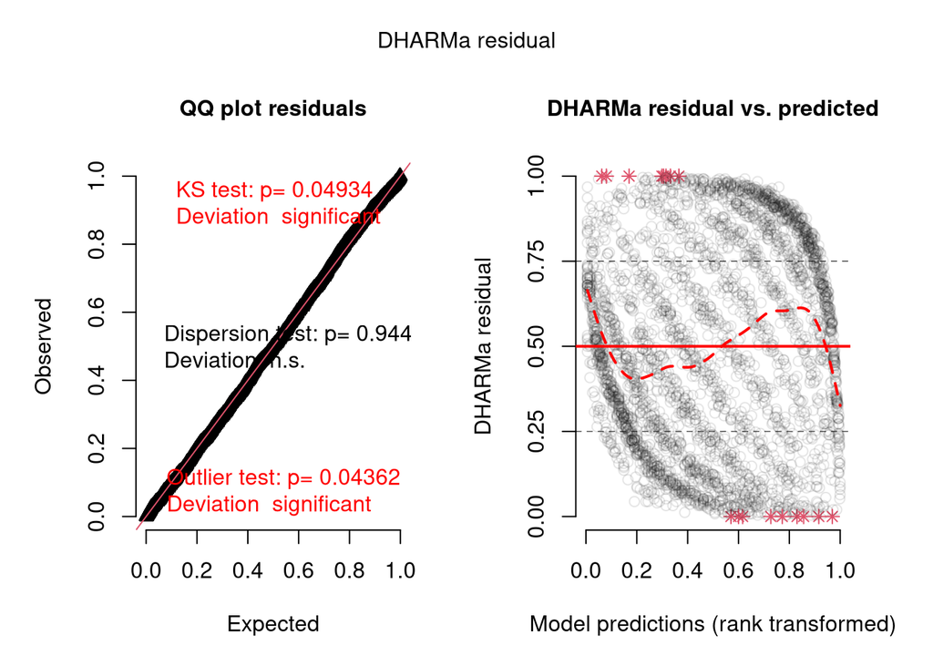

```r
sim_output<-DHARMa::simulateResiduals(model_3)
plot(sim_output)
```

[output not shown]

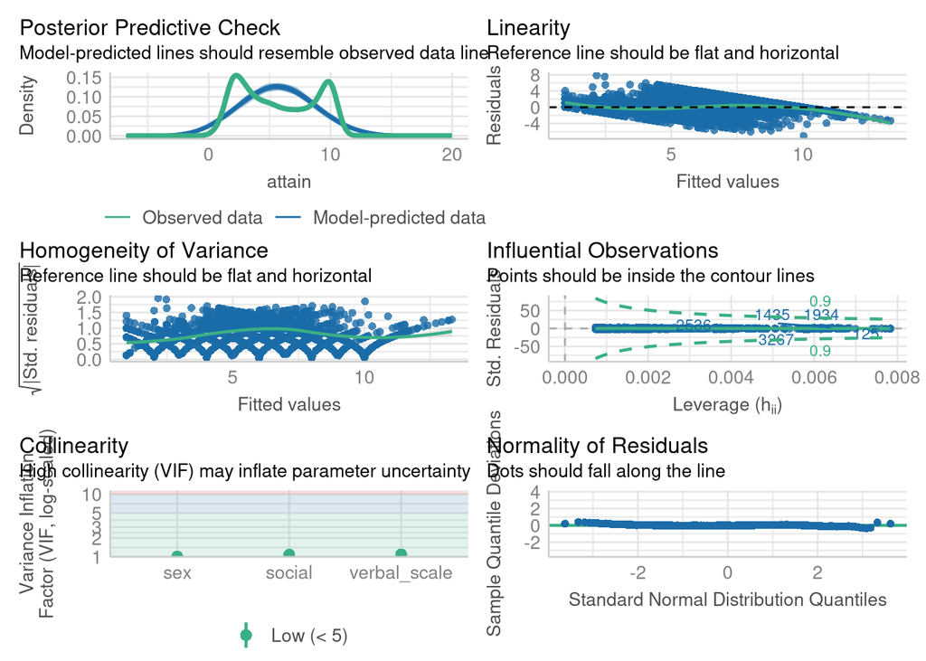

```r
performance::check_model(lm(attain~verbal_scale+sex+social,data))
```

To compare the diagnostics, we can analyze the plots of the fitted effects from both the linear model and the linear mixed model (which includes random effects). Additionally, we should include a plot that assesses the assumption of the random effects parameter, referred to as “Normality of Random Effects.”

## d.

fit the mixed model by other packages.

```r
model_nlm<-nlme::lme(attain~verbal_scale+sex+social, random= ~ sex|primary,data,method = "REML")

model_glmmTMB <- glmmTMB::glmmTMB(attain ~ verbal_scale+sex+social+(sex | primary),data= data,REML = TRUE)
```

## e.

Compare the different packages

```r
models<-list("lmer"=model_3,"lme"=model_nlm,"glmmTMB"=model_glmmTMB)

purrr::map_dfr(models,broom.mixed::glance,.id="model")
```

```
# A tibble: 3 × 9
  model    nobs sigma logLik    AIC    BIC REMLcrit df.residual deviance
  <chr>   <int> <dbl>  <dbl>  <dbl>  <dbl>    <dbl>       <int>    <dbl>
1 lmer     3435  2.01 -7338. 14695. 14757.   14675.        3425      NA
2 lme      3435  2.01 -7338. 14695. 14757.      NA           NA      NA
3 glmmTMB  3435  2.01 -7338. 14695. 14757.      NA         3425   13445.
```

It’s the same result.

## f.

Compare the different packages coefficients

```r
coefficients_dataframe<-purrr::map_dfr(models,~broom.mixed::tidy(., effects = "fixed"), .id = "model") |> dplyr::arrange(term)

# Compare the Intercept term
Intercept<-coefficients_dataframe|> dplyr::filter(term=="(Intercept)")|> dplyr::select("model","effect","term","estimate","std.error", "df","p.value")
lmerlme_est<-all.equal(Intercept[1,4],Intercept[2,4],tolerance=10^-4)
lmerlme_sd<-all.equal(Intercept[1,5],Intercept[2,5],tolerance=10^-4)
lmerlme_df<-all.equal(Intercept[1,6],Intercept[2,6])
lmerlme_pvalue<-all.equal(Intercept[1,7],Intercept[2,7],tolerance=10^-4)
lmerglmmTMB_est<-all.equal(Intercept[1,4],Intercept[3,4],tolerance=10^-4)
lmerglmmTMB_sd<-all.equal(Intercept[1,5],Intercept[3,5],tolerance=0.01)
lmerglmmTMB_df<-all.equal(Intercept[1,6],Intercept[3,6])
lmerglmmTMB_p<-all.equal(Intercept[1,7],Intercept[3,7],tolerance=10^-4)
lmeglmmTMB_est<-all.equal(Intercept[2,4],Intercept[3,4],tolerance=10^-4)
lmeglmmTMB_sd<-all.equal(Intercept[2,5],Intercept[3,5],tolerance=0.01)
lmeglmmTMB_df<-all.equal(Intercept[2,6],Intercept[3,6],tolerance=1)
lmeglmmTMB_pvalue<-all.equal(Intercept[2,7],Intercept[3,7],tolerance=10^-4)

# Compare the sexF term
sexF<-coefficients_dataframe|>dplyr::filter(term=="sexF")|>dplyr::select("model","effect","term","estimate","std.error", "df","p.value")
lmerlme_est<-all.equal(sexF[1,4],sexF[2,4],tolerance=10^-4)
lmerlme_sd<-all.equal(sexF[1,5],sexF[2,5],tolerance=10^-4)
lmerlme_df<-all.equal(sexF[1,6],sexF[2,6])
lmerlme_pvalue<-all.equal(sexF[1,7],sexF[2,7],tolerance=0.1)
lmerglmmTMB_est<-all.equal(sexF[1,4],sexF[3,4],tolerance=10^-4)
lmerglmmTMB_sd<-all.equal(sexF[1,5],sexF[3,5],tolerance=0.01)
lmerglmmTMB_df<-all.equal(sexF[1,6],sexF[3,6])
lmerglmmTMB_p<-all.equal(sexF[1,7],sexF[3,7],tolerance=0.1)
lmeglmmTMB_est<-all.equal(sexF[2,4],sexF[3,4],tolerance=10^-4)
lmeglmmTMB_sd<-all.equal(sexF[2,5],sexF[3,5],tolerance=0.01)
lmeglmmTMB_df<-all.equal(sexF[2,6],sexF[3,6])
lmeglmmTMB_pvalue<-all.equal(sexF[2,7],sexF[3,7],tolerance=0.1)

# Compare the social1 term
social1<-coefficients_dataframe|>dplyr::filter(term=="social1")|>dplyr::select("model","effect","term","estimate","std.error", "df","p.value")
lmerlme_est<-all.equal(social1[1,4],social1[2,4],tolerance=10^-4)
lmerlme_sd<-all.equal(social1[1,5],social1[2,5],tolerance=10^-4)
lmerlme_df<-all.equal(social1[1,6],social1[2,6])
lmerlme_pvalue<-all.equal(social1[1,7],social1[2,7],tolerance=10^-4)
lmerglmmTMB_est<-all.equal(social1[1,4],social1[3,4],tolerance=10^-4)
lmerglmmTMB_sd<-all.equal(social1[1,5],social1[3,5],tolerance=0.1)
lmerglmmTMB_df<-all.equal(social1[1,6],social1[3,6])
lmerglmmTMB_p<-all.equal(social1[1,7],social1[3,7],tolerance=10^-4)
lmeglmmTMB_est<-all.equal(social1[2,4],social1[3,4],tolerance=10^-4)
lmeglmmTMB_sd<-all.equal(social1[2,5],social1[3,5],tolerance=0.1)
lmeglmmTMB_df<-all.equal(social1[2,6],social1[3,6])
lmeglmmTMB_pvalue<-all.equal(social1[2,7],social1[3,7],tolerance=10^-4)

# compare the social20 term
social20<-coefficients_dataframe|>dplyr::filter(term=="social20")|>dplyr::select("model","effect","term","estimate","std.error", "df","p.value")
lmerlme_est<-all.equal(social20[1,4],social20[2,4],tolerance=10^-4)
lmerlme_sd<-all.equal(social20[1,5],social20[2,5],tolerance=10^-4)
lmerlme_df<-all.equal(social20[1,6],social20[2,6],tolerance=0.1)
lmerlme_pvalue<-all.equal(social20[1,7],social20[2,7],tolerance=10^-4)
lmerglmmTMB_est<-all.equal(social20[1,4],social20[3,4],tolerance=10^-4)
lmerglmmTMB_sd<-all.equal(social20[1,5],social20[3,5],tolerance=0.1)
lmerglmmTMB_df<-all.equal(social20[1,6],social20[3,6])
lmerglmmTMB_p<-all.equal(social20[1,7],social20[3,7],tolerance=10^-4)
lmeglmmTMB_est<-all.equal(social20[2,4],social20[3,4],tolerance=10^-4)
lmeglmmTMB_sd<-all.equal(social20[2,5],social20[3,5],tolerance=0.1)
lmeglmmTMB_df<-all.equal(social20[2,6],social20[3,6])
lmeglmmTMB_pvalue<-all.equal(social20[2,7],social20[3,7],tolerance=10^-4)

# compare the social31 term
social31<-coefficients_dataframe|>dplyr::filter(term=="social31")|>dplyr::select("model","effect","term","estimate","std.error", "df","p.value")
lmerlme_est<-all.equal(social31[1,4],social31[2,4],tolerance=10^-4)
lmerlme_sd<-all.equal(social31[1,5],social31[2,5],tolerance=10^-4)
lmerlme_df<-all.equal(social31[1,6],social31[2,6],tolerance=0.1)
lmerlme_pvalue<-all.equal(social31[1,7],social31[2,7],tolerance=10^-4)
lmerglmmTMB_est<-all.equal(social31[1,4],social31[3,4],tolerance=10^-4)
lmerglmmTMB_sd<-all.equal(social31[1,5],social31[3,5],tolerance=0.01)
lmerglmmTMB_df<-all.equal(social31[1,6],social31[3,6])
lmerglmmTMB_p<-all.equal(social31[1,7],social31[3,7],tolerance=10^-4)
lmeglmmTMB_est<-all.equal(social31[2,4],social31[3,4],tolerance=10^-4)
lmeglmmTMB_sd<-all.equal(social31[2,5],social31[3,5],tolerance=0.01)
lmeglmmTMB_df<-all.equal(social31[2,6],social31[3,6])
lmeglmmTMB_pvalue<-all.equal(social31[2,7],social31[3,7],tolerance=10^-4)

# compare the  verbal_scale term
verbal_scale<-coefficients_dataframe|>dplyr::filter(term=="verbal_scale")|>dplyr::select("model","effect","term","estimate","std.error", "df","p.value")
lmerlme_est<-all.equal(verbal_scale[1,4],verbal_scale[2,4],tolerance=10^-4)
lmerlme_sd<-all.equal(verbal_scale[1,5],verbal_scale[2,5],tolerance=10^-4)
lmerlme_df<-all.equal(verbal_scale[1,6],verbal_scale[2,6],tolerance=0.1)
lmerlme_pvalue<-all.equal(verbal_scale[1,7],verbal_scale[2,7],tolerance=10^-4)
lmerglmmTMB_est<-all.equal(verbal_scale[1,4],verbal_scale[3,4],tolerance=10^-4)
lmerglmmTMB_sd<-all.equal(verbal_scale[1,5],verbal_scale[3,5],tolerance=0.01)
lmerglmmTMB_df<-all.equal(verbal_scale[1,6],verbal_scale[3,6])
lmerglmmTMB_p<-all.equal(verbal_scale[1,7],verbal_scale[3,7],tolerance=10^-4)
lmeglmmTMB_est<-all.equal(verbal_scale[2,4],verbal_scale[3,4],tolerance=10^-4)
lmeglmmTMB_sd<-all.equal(verbal_scale[2,5],verbal_scale[3,5],tolerance=0.01)
lmeglmmTMB_df<-all.equal(verbal_scale[2,6],verbal_scale[3,6])
lmeglmmTMB_pvalue<-all.equal(verbal_scale[2,7],verbal_scale[3,7],tolerance=10^-4)
## BMB: try to repeat less code ... and not to cut-and-paste results (output should be programmatic)
```

1).Intercept * lmer & lme- estimation:equivalent; standard errors:equivalent; df:different; p value:equivalent * lmer & glmmTMB- estimation:equivalent; standard errors:very similar; df:NA; p value:equivalent * lme & glmmTMB- estimation:equivalent; standard errors:very similar; df:NA; p value:equivalent

2).sexF * lmer & lme- estimation:equivalent; standard errors:equivalent; df:different; p value:slightly different * lmer & glmmTMB- estimation:equivalent; standard errors:equivalent; df:NA; p value:slightly different * lme & glmmTMB- estimation:equivalent; standard errors:very similar; df:NA; p value:slightly different

3).social1 * lmer & lme- estimation:equivalent; standard errors:equivalent; df:different; p value:equivalent * lmer & glmmTMB- estimation:equivalent; standard errors:sightly different; df:NA; p value:equivalent * lme & glmmTMB- estimation:equivalent; standard errors:sightly different; df:NA; p value:equivalent

4).social20 * lmer & lme- estimation:equivalent; standard errors:equivalent; df:slightly different; p value:equivalent * lmer & glmmTMB- estimation:equivalent; standard errors:sightly different; df:NA; p value:equivalent * lme & glmmTMB- estimation:equivalent; standard errors:sightly different; df:NA; p value:equivalent

5).social31 * lmer & lme- estimation:equivalent; standard errors:equivalent; df:slightly different; p value:equivalent * lmer & glmmTMB- estimation:equivalent; standard errors:very similar; df:NA; p value:equivalent * lme & glmmTMB- estimation:equivalent; standard errors:very similar; df:NA; p value:equivalent

6).verbal_scale * lmer & lme- estimation:equivalent; standard errors:equivalent; df:slightly different; p value:equivalent * lmer & glmmTMB- estimation:equivalent; standard errors:very similar; df:NA; p value:equivalent * lme & glmmTMB- estimation:equivalent; standard errors:very similar; df:NA; p value:equivalent

## g.

compare the coefficient plot with the different models

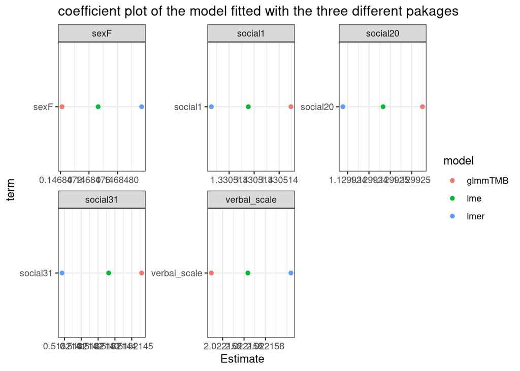

```r
# method 1, by the ggplot with the data frame
coefficients_dataframe$model<-as.factor(coefficients_dataframe$model)
coefficients_dataframe$term<-as.factor(coefficients_dataframe$term)
coefficients_dataframe|>dplyr::filter(term != "(Intercept)")|> ggplot2::ggplot(aes(y=term,x=estimate,colour=model ))+geom_point()+facet_wrap(~term,scales = "free")+labs(x="Estimate",title = "coefficient plot of the model fitted with the three different pakages")+theme_bw()
```

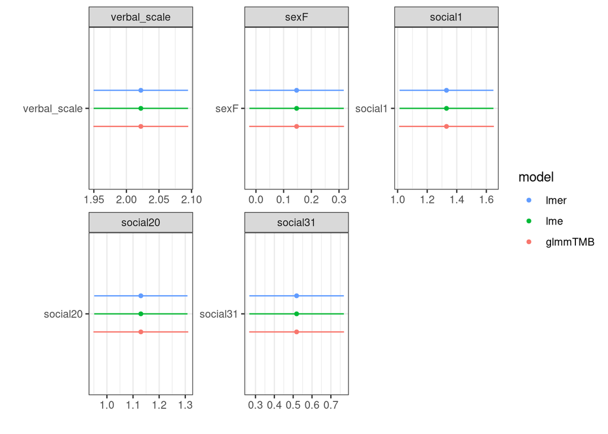

```r
# method 2, by the dotwhiskerpackage
dotwhisker::dwplot(models,effects="fixed")+facet_wrap(~ term,scales = "free")+theme_bw()
```

## h.

compare the two approaches that are to compute the denominator df

```r
dflmer_1<-coef(summary(model_3,ddf="Satterthwaite"))[,"df"]
dflmer_2<-coef(summary(model_3,ddf = "Kenward-Roger"))[,"df"]
dflme<-coef(summary(model_nlm))[,"DF"]
compare_df<-data.frame(lmer_sa=dflmer_1,lmer_ken=dflmer_2,lme=dflme)

compare_df
```

```
               lmer_sa  lmer_ken  lme
(Intercept)   155.5286  155.5286 3282
verbal_scale 3390.0592 3390.0592 3282
sexF          100.2033  100.2033 3282
social1      3365.7651 3365.7651 3282
social20     3367.5014 3367.5014 3282
social31     3405.3106 3405.3106 3282
```

## i.

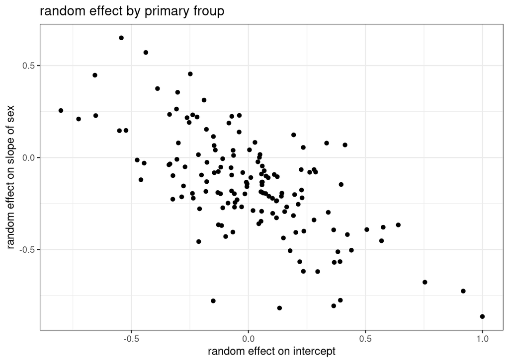

```r
random_effect_group<-lme4::ranef(model_3)$primary
fixed_sexslope<-glmmTMB::fixef(model_3)["sexF"]
random_effect_group$sex_deviation<-random_effect_group$sexF-fixed_sexslope
colnames(random_effect_group)[1]="Intercept"

random_effect_group|>ggplot2::ggplot(aes(x=Intercept,y=sex_deviation))+geom_point()+labs(x="random effect on intercept",y="random effect on slope of sex",title = "random effect by primary froup")+theme_bw()
```

It’s really interesting that it has the negative relationship between the random effect on intercept and on sex slope.(collinearity with the two random effect, should discard one)